# Uterine Leiomyoma GSE128242 15 women ECM, COL4A5, COL4A6, and MED12

Janis Corona

9/9/2020

%%%%%%%%%%%%%%%%%%%%%%%%%%%%%%%%%%%%%%%%%%%%%%%%%%%%%%%%%%%%%%%%%%%%%%%%

In the interest of my personal time, AKA being lazy to get to the point, here is the basis of this analysis. I want to add the MeD12, COL4A5, COL4A6, HMGA2, and ECM or extracellular matrix genes from genecards.org to our developed body systems genes used in previous analysis of COVID-19, Ulcerative Colitis, Crohn’s Disease, and Rheumatoid Arthritis. This analysis is on uterine leiomyomas or ULs that impact many females and are responsible for 30% of all hysterectomies, as well as other discomforts by women. They are benign tumors and this study, explores the extracellular matrix or ECM genes and collagen genes and hormone genes of a certain type of UL in women. There were 15 women who were filtered from various hysterectomy samples that took a matched healty myometrium sample with a diseased state tissue sample of UL, but they specifically had a mutation in a transcription process of the 2nd exon among other specifications to do this study. The details in the referenced gene summary and article it refers to are below.

“In this study, freshly procured tissue samples from women who have undergone hysterectomies as a course of treatment for uterine leiomyomas, confirmed to have a glycine-to-aspartate (G44D) or glycine-to-serine (G44S) substitution in exon 2 of MED12, are used to characterize epigenetic changes in the disease. Adjacent, nondiseased areas of the myometrium from the same patients are also collected to represent normal (wild-type [WT]) samples. In an effort to avoid artifactual alterations to the transcriptomic and epigenomic profiles of patient samples, gene expression profiling by RNA-sequencing (RNA-seq) as well as epigenetic profiling by highresolution chromatin immunoprecipitation-sequencing (ChIP-seq) and promoter capture Hi-C are performed directly from tissue samples with minimal processing. Our integrative analysis of transcriptomic and epigenetic changes, highlighted by the near-native characterization of long-range promoter interactions in uterine fibroids, identifies differential transcription factor occupancy, differential enhancer engagement, and altered enhancer-promoter contacts as key events that drive gene dysregulation in leiomyomas. Results Transcriptome profiling of fibroids. We used RNA isolation followed by massively parallel sequencing (RNA-seq) to examine the transcriptome profiles of normal myometrium (WT) and matched leiomyoma (G44D/S) tissue obtained from 15 women. A high degree of similarity between biological replicates of myometrium transcriptome profiles was seen, with a similar observation among biological replicates of leiomyoma tissue samples. Hierarchical clustering of all RNA-seq datasets highlights clustering primarily by disease state (Fig. 1a). Significantly, principal component analysis of the most variable genes revealed that 43% of the variance (PC1) is explained by the disease state, with biological replicates co-segregating based on tissue type (Fig. 1b). This suggests that the changes in gene expression between normal and MED12 mutant disease tissue types are primarily attributable to biological pathways that are important for the” – GSE128242 NCBI study from the article associated with this study:

Series GSE128242 Query DataSets for GSE128242 Status Public on Jan 01, 2020 Title Altered chromatin landscape and enhancer engagement underlie transcriptional dysregulation in MED12 mutant uterine leiomyomas Organism Homo sapiens Experiment type Expression profiling by high throughput sequencing Genome binding/occupancy profiling by high throughput sequencing Other Summary This SuperSeries is composed of the SubSeries listed below.

Overall design Refer to individual Series

Citation(s) Moyo MB, Parker JB, Chakravarti D. Altered chromatin landscape and enhancer engagement underlie transcriptional dysregulation in MED12 mutant uterine leiomyomas. Nat Commun 2020 Feb 24;11(1):1019. PMID: 32094355 Submission date Mar 13, 2019 Last update date Mar 09, 2020 Contact name Debabrata Chakravarti E-mail(s) debu@northwestern.edu

%%%%%%%%%%%%%%%%%%%%%%%%%%%%%%%%%%%%%%%%%%%%%%%%%%%%%%%%%%%%%%%%%%%%%%%%%%%%%%

Lets use our functions for gathering the genecards.org genes related to the above mentioned genes of the ECM, COL4A5, COL4A6, MED12, and HMGA2.

```r
library(dplyr)
library(tidyr)
```

```r
source('geneCards2.R')
```

```r
bodySystemGenes <- read.csv('bodySystemGenes.csv')
head(bodySystemGenes)
```

Lets just keep the first 5 features. The other features are from an Ulcerative Colitis and Crohn’s Disease analysis in GSE135223.

```r
BS1 <- bodySystemGenes[,1:5]
```

```r
find25genes('ECM')
find25genes('hormone')
find25genes('collagen')
find25genes('transcription')
```

```r
getProteinGenes('ECM')
getProteinGenes('hormone')
getProteinGenes('collagen')
getProteinGenes('transcription')
```

```r
ecm <- read.csv("Top25ecms.csv")
collagen <- read.csv("Top25hormones.csv")
hormone <- read.csv("Top25collagens.csv")
transcription <- read.csv("Top25transcriptions.csv")
```

```r
for (i in ecm$proteinType){
  getSummaries2(i,'ECM')
}

for (i in collagen$proteinType){
  getSummaries2(i,'collagen')
}

for (i in hormone$proteinType){
  getSummaries2(i,'hormone')
}

for (i in transcription$proteinType){
  getSummaries2(i,'transcription')
}
```

```r
find25genes('HMGA2')
find25genes('MED12')
find25genes('COL4A6')
find25genes('COL4A5')
```

```r
hmga2 <- read.csv("Top25hmga2s.csv")
med12 <- read.csv('Top25med12s.csv')
col4a5 <- read.csv('Top25col4a5s.csv')
col4a6 <- read.csv('Top25col4a6s.csv')
```

```r
for (i in hmga2$proteinType){
  getSummaries2(i,'hmga2')
}

for (i in med12$proteinType){
  getSummaries2(i,'med12')
}

for (i in col4a5$proteinType){
  getSummaries2(i, 'col4a5')
}

for (i in col4a6$proteinType){
  getSummaries2(i,'col4a6')
}
```

```r
getGeneSummaries('ECM')
getGeneSummaries('collagen')
getGeneSummaries('hormone')
getGeneSummaries('transcription')
getGeneSummaries('HMGA2')
getGeneSummaries('MED12')
getGeneSummaries('COL4A5')
getGeneSummaries('COL4A6')
```

```r
transcriptionSumms <- read.csv("proteinGeneSummaries_transcription.csv")
hormoneSumms <- read.csv("proteinGeneSummaries_hormone.csv")
collagenSumms <- read.csv("proteinGeneSummaries_collagen.csv")
ecmSumms <- read.csv("proteinGeneSummaries_ecm.csv")
med12Summs <- read.csv("proteinGeneSummaries_med12.csv")
col4a5Summs <- read.csv("proteinGeneSummaries_col4a5.csv")
col4a6Summs <- read.csv("proteinGeneSummaries_col4a6.csv")
hmga2Summs <- read.csv("proteinGeneSummaries_hmga2.csv")
```

```r
newSumms <- rbind(transcriptionSumms,hormoneSumms,
                  collagenSumms,ecmSumms,
                  med12Summs,col4a5Summs,col4a6Summs,
                  hmga2Summs)
colnames(newSumms)
NS <- newSumms[,c(2,1,4:6)]

bodySystems2 <- rbind(BS1,NS)
```

```r
write.csv(bodySystems2,'bodySystems2.csv',row.names=F)
```

%%%%%%%%%%%%%%%%%%%%%%%%%%%%%%%%%%%%%%%%%%%%%%%%%%%%%%%%%%%%%

We now have our genes that we are going to be working with. The other genes only use the top 3 ranked genes related to those systems of the body, but these new additions related to UL and this study resource have 25 top ranked genes for each of our 8 gene systems related to collagen, hormones, transcription, and the extracellular matrix. There are a few duplicates, of COL4A5 and one other that were researched for top genes, because they weren’t the top 3 ranked genes of those other mentioned body system genes, and some weren’t even the top25 ranked genes for those body systems like COL4A6 and HMGA2. Lets clean out our environment in Rstudio and read in our new body system genes.

```r
bodySystems2 <- read.csv('bodySystems2.csv',stringsAsFactors = T)
```

Lets now read in our UL data from GSE128242

```r
UL <- read.delim('GSE128229_RNA_Tissue_DESeq2.txt',sep='\t',header=T)
```

```r
DF <- merge(bodySystems2,UL,by.x='gene',by.y='symbol')
```

```r
head(DF)
```

```
##    gene proteinSearched
## 1 AANAT       melatonin
## 2 AANAT       melatonin
## 3 AANAT       melatonin
## 4 AANAT       melatonin
## 5 AANAT       melatonin
## 6 AANAT       melatonin
##                                                                                                                                                                                                                                                                                                          …
## 1 The protein encoded by this gene belongs to the acetyltransferase superfamily. It is the penultimate enzyme in melatonin synthesis and controls the night/day rhythm in melatonin production in the vertebrate pineal gland. Melatonin is essential for the function of the circadian clock that influe…
## 2 The protein encoded by this gene belongs to the acetyltransferase superfamily. It is the penultimate enzyme in melatonin synthesis and controls the night/day rhythm in melatonin production in the vertebrate pineal gland. Melatonin is essential for the function of the circadian clock that influe…
## 3 The protein encoded by this gene belongs to the acetyltransferase superfamily. It is the penultimate enzyme in melatonin synthesis and controls the night/day rhythm in melatonin production in the vertebrate pineal gland. Melatonin is essential for the function of the circadian clock that influe…
## 4 The protein encoded by this gene belongs to the acetyltransferase superfamily. It is the penultimate enzyme in melatonin synthesis and controls the night/day rhythm in melatonin production in the vertebrate pineal gland. Melatonin is essential for the function of the circadian clock that influe…
## 5 The protein encoded by this gene belongs to the acetyltransferase superfamily. It is the penultimate enzyme in melatonin synthesis and controls the night/day rhythm in melatonin production in the vertebrate pineal gland. Melatonin is essential for the function of the circadian clock that influe…
## 6 The protein encoded by this gene belongs to the acetyltransferase superfamily. It is the penultimate enzyme in melatonin synthesis and controls the night/day rhythm in melatonin production in the vertebrate pineal gland. Melatonin is essential for the function of the circadian clock that influe…
##                                                                                                                                                                                                                                                                                                          …
```

[output cut: 55 more lines]

```r
colnames(DF) <- gsub('GeneID','EnsemblID',colnames(DF))
colnames(DF) <- gsub('entrez','EntrezID',colnames(DF))
colnames(DF)
```

```
##  [1] "gene"              "proteinSearched"   "EntrezSummary"
##  [4] "GeneCardsSummary"  "UniProtKB_Summary" "EnsemblID"
##  [7] "baseMean"          "log2FoldChange"    "lfcSE"
## [10] "pvalue"            "padj"              "biotype"
## [13] "EntrezID"          "MYO_PT728"         "MYO_PT758"
## [16] "MYO_PT1063"        "MYO_PT1113"        "MYO_PT1119"
## [19] "MYO_PT1123"        "MYO_PT1151"        "MYO_PT354"
## [22] "MYO_PT563"         "MYO_PT845"         "MYO_PT848"
## [25] "MYO_PT886"         "MYO_PT916"         "MYO_PT967"
## [28] "MYO_PTc57"         "LEIO_PT728"        "LEIO_PT758"
## [31] "LEIO_PT1063"       "LEIO_PT1113"       "LEIO_PT1119"
## [34] "LEIO_PT1123"       "LEIO_PT1151"       "LEIO_PT354"
## [37] "LEIO_PT563"        "LEIO_PT845"        "LEIO_PT848"
## [40] "LEIO_PT886"        "LEIO_PT916"        "LEIO_PT967"
## [43] "LEIO_PTc57"
```

```r
bodySystems3 <- DF[,c(1:6,13)]
bs3 <- bodySystems3[!duplicated(bodySystems3),]

write.csv(bs3,'bodySystems3.csv',row.names=F)
```

```r
DF2 <- DF[!duplicated(DF),c(1:6,14:43)]
row.names(DF2) <- NULL
```

```r
head(DF2)
```

```
##    gene      proteinSearched
## 1 AANAT            melatonin
## 2 ACSL4               col4a5
## 3 ACTA1                fiber
## 4 ADH1B              alcohol
## 5 ADH1C              alcohol
## 6   ALB green-coffee-extract
##                                                                                                                                                                                                                                                                                                          …
## 1                                                                 The protein encoded by this gene belongs to the acetyltransferase superfamily. It is the penultimate enzyme in melatonin synthesis and controls the night/day rhythm in melatonin production in the vertebrate pineal gland. Melatonin …
## 2                                                                                                                                                          The protein encoded by this gene is an isozyme of the long-chain fatty-acid-coenzyme A ligase family. Although differing in substrate specific…
## 3 The product encoded by this gene belongs to the actin family of proteins, which are highly conserved proteins that play a role in cell motility, structure and integrity. Alpha, beta and gamma actin isoforms have been identified, with alpha actins being a major constituent of the contractile app…
## 4                                                                                                     The protein encoded by this gene is a member of the alcohol dehydrogenase family. Members of this enzyme family metabolize a wide variety of substrates, including ethanol, retinol, other aliphati…
## 5                           This gene encodes class I alcohol dehydrogenase, gamma subunit, which is a member of the alcohol dehydrogenase family. Members of this enzyme family metabolize a wide variety of substrates, including ethanol, retinol, other aliphatic alcohols, hydroxysteroids, and lipi…
## 6                                                                                                                                                                           This gene encodes the most abundant protein in human blood. This protein functions in the regulation of blood plasma colloid …
##                                                                                                                                                                                                                                                                                                          …
```

[output cut: 48 more lines]

These are matched samples and the last alphanumeric identifier tag matches the ‘MYO’ with the ‘LEIO’ samples from matched uterus samples from hysterectomies. We will shorten the tag ID to 1-15 instead of PT728-PTc57.They are in order already and not mismatched.

```r
colnames(DF2)
```

```
##  [1] "gene"              "proteinSearched"   "EntrezSummary"
##  [4] "GeneCardsSummary"  "UniProtKB_Summary" "EnsemblID"
##  [7] "MYO_PT728"         "MYO_PT758"         "MYO_PT1063"
## [10] "MYO_PT1113"        "MYO_PT1119"        "MYO_PT1123"
## [13] "MYO_PT1151"        "MYO_PT354"         "MYO_PT563"
## [16] "MYO_PT845"         "MYO_PT848"         "MYO_PT886"
## [19] "MYO_PT916"         "MYO_PT967"         "MYO_PTc57"
## [22] "LEIO_PT728"        "LEIO_PT758"        "LEIO_PT1063"
## [25] "LEIO_PT1113"       "LEIO_PT1119"       "LEIO_PT1123"
## [28] "LEIO_PT1151"       "LEIO_PT354"        "LEIO_PT563"
## [31] "LEIO_PT845"        "LEIO_PT848"        "LEIO_PT886"
## [34] "LEIO_PT916"        "LEIO_PT967"        "LEIO_PTc57"
```

```r
DF3 <- DF2
names <- c(paste(rep('healthy',15),1:15,sep='_'),
           paste(rep('leiomyoma',15),1:15,sep='_'))
colnames(DF3)[7:36] <- names
colnames(DF3)
```

```
##  [1] "gene"              "proteinSearched"   "EntrezSummary"
##  [4] "GeneCardsSummary"  "UniProtKB_Summary" "EnsemblID"
##  [7] "healthy_1"         "healthy_2"         "healthy_3"
## [10] "healthy_4"         "healthy_5"         "healthy_6"
## [13] "healthy_7"         "healthy_8"         "healthy_9"
## [16] "healthy_10"        "healthy_11"        "healthy_12"
## [19] "healthy_13"        "healthy_14"        "healthy_15"
## [22] "leiomyoma_1"       "leiomyoma_2"       "leiomyoma_3"
## [25] "leiomyoma_4"       "leiomyoma_5"       "leiomyoma_6"
## [28] "leiomyoma_7"       "leiomyoma_8"       "leiomyoma_9"
## [31] "leiomyoma_10"      "leiomyoma_11"      "leiomyoma_12"
## [34] "leiomyoma_13"      "leiomyoma_14"      "leiomyoma_15"
```

```r
DF4 <- DF3 %>% group_by(gene) %>% count(gene)

colnames(DF4)[2] <- 'geneCounts_GSE128242'
```

```r
DF5 <- DF3 %>% group_by(gene) %>% summarise_at(vars('healthy_1':'leiomyoma_15'),mean)

DF5$healthyMean <- apply(DF5[,2:16],1,mean)
DF5$leiomyomaMean <- apply(DF5[,17:31],1,mean)
DF5$LEIO_Healthy_foldChange <- ifelse(DF5$leiomyomaMean/DF5$healthyMean=='Inf',
  1+DF5$leiomyomaMean,
ifelse(DF5$leiomyomaMean/DF5$healthyMean=='NaN',1,
ifelse(DF5$leiomyomaMean/DF5$healthyMean<=0,
  1-DF5$healthyMean,DF5$leiomyomaMean/DF5$healthyMean)))
head(DF5)
```

```
## # A tibble: 6 x 34
##   gene  healthy_1 healthy_2 healthy_3 healthy_4 healthy_5 healthy_6 healthy_7
##   <fct>     <dbl>     <dbl>     <dbl>     <dbl>     <dbl>     <dbl>     <dbl>
## 1 AANAT     0.800      1.02      0        0.816     1.72       0        0
## 2 ACSL4  1307.       760.      746.     683.      995.       972.     841.
## 3 ACTA1     1.60       5.08      3.17     5.71      0.861      0        4.47
## 4 ADH1B  1277.       755.     1858.    1776.     2383.      1522.     984.
## 5 ADH1C     8.80       4.07     11.9     13.9      15.5        6.11     1.79
## 6 ALB       4.00       1.02      2.38     0.816     0.861      2.62     0.895
## # ... with 26 more variables: healthy_8 <dbl>, healthy_9 <dbl>,
## #   healthy_10 <dbl>, healthy_11 <dbl>, healthy_12 <dbl>, healthy_13 <dbl>,
## #   healthy_14 <dbl>, healthy_15 <dbl>, leiomyoma_1 <dbl>, leiomyoma_2 <dbl>,
## #   leiomyoma_3 <dbl>, leiomyoma_4 <dbl>, leiomyoma_5 <dbl>, leiomyoma_6 <dbl>,
## #   leiomyoma_7 <dbl>, leiomyoma_8 <dbl>, leiomyoma_9 <dbl>,
## #   leiomyoma_10 <dbl>, leiomyoma_11 <dbl>, leiomyoma_12 <dbl>,
## #   leiomyoma_13 <dbl>, leiomyoma_14 <dbl>, leiomyoma_15 <dbl>,
## #   healthyMean <dbl>, leiomyomaMean <dbl>, LEIO_Healthy_foldChange <dbl>
```

```r
DF6 <- merge(bs3,DF4,by.x='gene',by.y='gene')
```

```r
DF7 <- merge(DF6,DF5,by.x='gene',by.y='gene')
```

```r
colnames(DF7)
```

```
##  [1] "gene"                    "proteinSearched"
##  [3] "EntrezSummary"           "GeneCardsSummary"
##  [5] "UniProtKB_Summary"       "EnsemblID"
##  [7] "EntrezID"                "geneCounts_GSE128242"
##  [9] "healthy_1"               "healthy_2"
## [11] "healthy_3"               "healthy_4"
## [13] "healthy_5"               "healthy_6"
## [15] "healthy_7"               "healthy_8"
## [17] "healthy_9"               "healthy_10"
## [19] "healthy_11"              "healthy_12"
## [21] "healthy_13"              "healthy_14"
## [23] "healthy_15"              "leiomyoma_1"
## [25] "leiomyoma_2"             "leiomyoma_3"
## [27] "leiomyoma_4"             "leiomyoma_5"
## [29] "leiomyoma_6"             "leiomyoma_7"
## [31] "leiomyoma_8"             "leiomyoma_9"
## [33] "leiomyoma_10"            "leiomyoma_11"
## [35] "leiomyoma_12"            "leiomyoma_13"
## [37] "leiomyoma_14"            "leiomyoma_15"
## [39] "healthyMean"             "leiomyomaMean"
## [41] "LEIO_Healthy_foldChange"
```

```r
head(DF7)
```

```
##    gene      proteinSearched
## 1 AANAT            melatonin
## 2 ACSL4               col4a5
## 3 ACTA1                fiber
## 4 ADH1B              alcohol
## 5 ADH1C              alcohol
## 6   ALB green-coffee-extract
##                                                                                                                                                                                                                                                                                                          …
## 1                                                                 The protein encoded by this gene belongs to the acetyltransferase superfamily. It is the penultimate enzyme in melatonin synthesis and controls the night/day rhythm in melatonin production in the vertebrate pineal gland. Melatonin …
## 2                                                                                                                                                          The protein encoded by this gene is an isozyme of the long-chain fatty-acid-coenzyme A ligase family. Although differing in substrate specific…
## 3 The product encoded by this gene belongs to the actin family of proteins, which are highly conserved proteins that play a role in cell motility, structure and integrity. Alpha, beta and gamma actin isoforms have been identified, with alpha actins being a major constituent of the contractile app…
## 4                                                                                                     The protein encoded by this gene is a member of the alcohol dehydrogenase family. Members of this enzyme family metabolize a wide variety of substrates, including ethanol, retinol, other aliphati…
## 5                           This gene encodes class I alcohol dehydrogenase, gamma subunit, which is a member of the alcohol dehydrogenase family. Members of this enzyme family metabolize a wide variety of substrates, including ethanol, retinol, other aliphatic alcohols, hydroxysteroids, and lipi…
## 6                                                                                                                                                                           This gene encodes the most abundant protein in human blood. This protein functions in the regulation of blood plasma colloid …
##                                                                                                                                                                                                                                                                                                          …
```

[output cut: 62 more lines]

```r
DF8 <- gather(DF7,key='sample',value='sampleValue',9:38)
ul <- grep('leio',DF8$sample)
healthy <- grep('healthy',DF8$sample)
DF8$group <- 'group'
DF8[ul,14] <- 'leiomyoma'
DF8[healthy,14] <- 'healthy myo'
unique(DF8$group)
```

```
## [1] "healthy myo" "leiomyoma"
```

```r
head(DF8)
```

```
##    gene      proteinSearched
## 1 AANAT            melatonin
## 2 ACSL4               col4a5
## 3 ACTA1                fiber
## 4 ADH1B              alcohol
## 5 ADH1C              alcohol
## 6   ALB green-coffee-extract
##                                                                                                                                                                                                                                                                                                          …
## 1                                                                 The protein encoded by this gene belongs to the acetyltransferase superfamily. It is the penultimate enzyme in melatonin synthesis and controls the night/day rhythm in melatonin production in the vertebrate pineal gland. Melatonin …
## 2                                                                                                                                                          The protein encoded by this gene is an isozyme of the long-chain fatty-acid-coenzyme A ligase family. Although differing in substrate specific…
## 3 The product encoded by this gene belongs to the actin family of proteins, which are highly conserved proteins that play a role in cell motility, structure and integrity. Alpha, beta and gamma actin isoforms have been identified, with alpha actins being a major constituent of the contractile app…
## 4                                                                                                     The protein encoded by this gene is a member of the alcohol dehydrogenase family. Members of this enzyme family metabolize a wide variety of substrates, including ethanol, retinol, other aliphati…
## 5                           This gene encodes class I alcohol dehydrogenase, gamma subunit, which is a member of the alcohol dehydrogenase family. Members of this enzyme family metabolize a wide variety of substrates, including ethanol, retinol, other aliphatic alcohols, hydroxysteroids, and lipi…
## 6                                                                                                                                                                           This gene encodes the most abundant protein in human blood. This protein functions in the regulation of blood plasma colloid …
##                                                                                                                                                                                                                                                                                                          …
```

[output cut: 27 more lines]

```r
write.csv(DF8,'UL_FCs_systemGenes.csv',row.names=F)
```

What would be great, would be to combine these genes and the UL data or uterine leiomyoma data of this study with another UL study, the COVID-19 study, the Rheumatoid Arthritis study, and the ulcerative colitis and Crohn’s disease. We will do this and then make an interactive Tableau dashboard that will allow for selecting the body system, gene, and disease values to see the fold change, mean values per group comparison of healthy and diseased or treated, and the individual sample values in that disease study groups. Some names of columns will have to be changed so that instead of a merge we row bind the needed fields together and drop unneeded ones like the gene counts per gene of that particular study when dealing with copy number variants we didn’t show. Or we can add it in to those studies that didn’t have it added. The body system genes we now have should be added to the orginal data of those studies as we bring the larger data of each study into this analysis.

I emptied out the environment and want to read in all of our data we want to combine. We have variations on the fold change values from each study if there are any fold change values added to the data. Also, the Lyme disease study has log2 normalized data that is probably quantile normalized, hence the negative values, but I want positive values, so I am going to take every value in that data and raise it as an exponent of base 2, so that they are positive, and log2 is done after normalization, so it is closer to the raw values. Some of the data also has the copy number variants of genes as the disease study gene counts of genes. Lets read in all our data first, then look at the differences.

```r
UL_study1 <- read.csv('UL_studyGSE120854_fCs.csv',
                      sep=',',
                      header=T, na.strings=c('',' ','NA'),
                      stringsAsFactors = T)
UL_study2 <- read.csv('UL_FCs_systemGenes.csv',
                      sep=',',
                      header=T, na.strings=c('',' ','NA'),
                      stringsAsFactors = T)
UC_CD <- read.csv('allRawDataCombinedGSE135223_UC_CD.csv',
                      sep=',',
                      header=T, na.strings=c('',' ','NA'),
                      stringsAsFactors = T)
LymeDisease <- read.csv('LymeDisease_log2norm.csv',
                        sep=',',
                      header=T, na.strings=c('',' ','NA'),
                      stringsAsFactors = T)
RA <- read.csv('RA_data_fcs.csv',
               sep=',',
                      header=T, na.strings=c('',' ','NA'),
                      stringsAsFactors = T)
covid19 <- read.csv('DATA_FCs_GSE152418_covid19.csv',
                    sep=',',
                      header=T, na.strings=c('',' ','NA'),
                      stringsAsFactors = T)
```

The RA and both UL studys have gene counts, but the COVID19 doesn’t because each gene only had one version of itself, and also doesn’t have the gene counts column. This was verified by going back to the script that made that file v3 of the original and grouping by the ENSEMBLID to get the count and seeing the only value was 1 and the number of genes was the same as the number of genes in total. The Lyme disease data hasn’t had any aggregate sums done to it, because it still needs to all be converted to having each value the power of base 2 to reverse the log2 and make all values positive. The Ulcerative Colitis and Crohns disease data doesn’t have the gene counts of its data set, but also there weren’t any aggregations done to this data, so we can get the gene counts of the UC_CD, LymeDisease, and covid19 data sets in this script.

```r
cv19 <- covid19 %>% group_by(ENSEMBLID) %>% count(ENSEMBLID)
colnames(cv19)[2] <- 'cv19_geneCount'

covid19b <- merge(cv19,covid19,by.x='ENSEMBLID',by.y='ENSEMBLID')
```

```r
uccd <- UC_CD %>% group_by(Ensembl_ID) %>% count(Ensembl_ID)
colnames(uccd)[2] <- 'UC_CD_geneCount'

UC_CDb <- merge(uccd,UC_CD,by.x='Ensembl_ID',by.y='Ensembl_ID')
```

```r
ld <- LymeDisease %>% group_by(Gene) %>% count(Gene)
colnames(ld)[2] <- 'Lyme_geneCount'

LymeDisease2 <- merge(ld,LymeDisease,by.x='Gene',by.y='Gene')

LymeDisease3 <- LymeDisease2[complete.cases(LymeDisease2$Gene),]

LymeDisease4 <- LymeDisease3[,-c(1:2)]
LymeDisease4 <- 2^(LymeDisease4) #inverse log2 on data
LymeDisease5 <- cbind(LymeDisease3[,1:2],LymeDisease4)

#the GSM ID header isn't useful, we'll read in the header data for this study
metaLyme <- read.csv('descriptors2.csv')
metaLyme$Sample_Title <- as.character(paste(metaLyme$Sample_Title))

metaLyme$Sample_Title <- gsub('PBMC total RNA-Healthy control ',
                              'healthy_Lyme_',metaLyme$Sample_Title)
metaLyme$Sample_Title <- gsub('PBMC total RNA-Acute Lyme disease subject ',
                              'acuteLyme_',metaLyme$Sample_Title)
metaLyme$Sample_Title <- gsub('PBMC total RNA-early convalescent Lyme disease subject ','Lyme_anti1month_',metaLyme$Sample_Title)
metaLyme$Sample_Title <- gsub('PBMC total RNA-late convalescent Lyme disease subject ','Lyme_anti6months_',metaLyme$Sample_Title)

colnames(LymeDisease5)[3:88]<-metaLyme$Sample_Title
```

```r
colnames(covid19b)[2] <- 'geneCount'
colnames(LymeDisease5)[1:2] <- c('gene','geneCount')
colnames(RA)[2] <- 'geneCount'
colnames(UC_CDb)[2] <- 'geneCount'
colnames(UL_study1)[2] <- 'geneCount'
colnames(UL_study2)[8] <- 'geneCount'
```

```r
RA$group <- 'group'
healthy <- grep('healthy',RA$sample)
treatment <- grep('treatment',RA$sample)
RA[healthy,8] <- 'healthy RA'
RA[treatment,8] <- 'treatment RA abatacept'

RA2 <- gather(RA,key='groupMean',value='groupMeanValue',3:4)
RA3 <- gather(RA2,key='foldChangeGroup',value='foldChangeGroupValue',3)
```

```r
covid19b2 <- gather(covid19b,key='sample',value='sampleValue',3:36)
covid19b2$group <- 'group'
conv <- grep('convalescent',covid19b2$sample)
healthy <- grep('healthy',covid19b2$sample)
mod <- grep('moderate',covid19b2$sample)
severe <- grep('severe',covid19b2$sample)
icu <- grep('ICU',covid19b2$sample)

covid19b2[conv,12] <- 'convalescent cv19'
covid19b2[healthy,12] <- 'healthy cv19'
covid19b2[mod,12] <- 'moderate cv19'
covid19b2[severe,12] <- 'severe cv19'
covid19b2[icu,12] <- 'ICU cv19'

cv1 <- covid19b2

cv2 <- gather(cv1,key='groupMean',value='groupMeanValue',3:6)
cv3 <- gather(cv2, key='foldChangeGroup',value='foldChangeGroupValue',3:5)
```

```r
UL_study1b <- gather(UL_study1,key='groupMean',value='groupMeanValue',3:4)
UL_study1c <- gather(UL_study1b,key='foldChangeGroup',
                     value='foldChangeGroupValue',3)
```

```r
UL_Study2 <- UL_study2[,-c(2:7)]
UL_study2b <- gather(UL_Study2,key='groupMean',value='groupMeanValue',3:4)
UL_study2c <- gather(UL_study2b,key='foldChangeGroup',
                     value='foldChangeGroupValue',3)
```

The Lyme Disease and Ulcerative Colitis with Crohn’s Disease data needs to be grouped by their genes, get the group means, and the fold change values between the diseased or treated group means to the healthy group mean value per gene. Then gathered into the sample, mean, and fold change groups with corresponding values.

```r
LD <- LymeDisease5 %>% group_by(gene) %>% summarise_at(vars('healthy_Lyme_1':'Lyme_anti6months_10'),mean)

LD$healthyLymeMean <- apply(LD[,3:23],1,mean)
LD$acuteLymeMean <- apply(LD[24:51],1,mean)
LD$Lyme1monthMean <- apply(LD[52:78],1,mean)
LD$Lyme6monthsMean <- apply(LD[79:88],1,mean)

#use same fold change values as in RA samples
LD$acuteHealthyLymeFoldChange <- ifelse(LD$acuteLymeMean/LD$healthyLymeMean=='Inf',
  1+LD$acuteLymeMean,
ifelse(LD$acuteLymeMean/LD$healthyLymeMean=='NaN',1,
ifelse(LD$acuteLymeMean/LD$healthyLymeMean<=0,
  1-LD$healthyLymeMean,LD$acuteLymeMean/LD$healthyLymeMean)))

LD$month1HealthyLymeFoldChange <- ifelse(LD$Lyme1monthMean/LD$healthyLymeMean=='Inf',
  1+LD$Lyme1monthMean,
ifelse(LD$Lyme1monthMean/LD$healthyLymeMean=='NaN',1,
ifelse(LD$Lyme1monthMean/LD$healthyLymeMean<=0,
  1-LD$healthyLymeMean,LD$Lyme1monthMean/LD$healthyLymeMean)))

LD$month6HealthyLymeFoldChange <- ifelse(LD$Lyme6monthsMean/LD$healthyLymeMean=='Inf',
  1+LD$Lyme6monthsMean,
ifelse(LD$Lyme6monthsMean/LD$healthyLymeMean=='NaN',1,
ifelse(LD$Lyme6monthsMean/LD$healthyLymeMean<=0,
  1-LD$healthyLymeMean,LD$Lyme6monthsMean/LD$healthyLymeMean)))

LD0 <- LymeDisease5[,1:2]

LD01 <- merge(LD0,LD,by.x='gene',by.y='gene')
LD1 <- gather(LD01,key='sample',value='sampleValue',3:88)
LD1$group <- 'group'
healthy <- grep('healthy',LD1$sample)
acute <- grep('acute',LD1$sample)
month1 <- grep('anti1',LD1$sample)
month6 <- grep('anti6',LD1$sample)
LD1[healthy,12] <- 'healthy Lyme'
LD1[acute,12] <- 'acute Lyme'
LD1[month1,12] <- 'Lyme 1 month antibiotics'
LD1[month6,12] <- 'Lyme 6 months antibiotics'

LD2 <- gather(LD1, key='groupMean',value='groupMeanValue',3:6)
LD3 <- gather(LD2,key='foldChangeGroup',value='foldChangeGroupValue',3:5)
```

```r
uccb <- UC_CDb %>% group_by(Ensembl_ID) %>% summarise_at(vars('Crohns.Disease.rep.1':'Ulcerative.Colitis.rep.5'),mean)

uccb2 <- UC_CDb[,1:2]
uccb2a <- merge(uccb2,uccb,by.x='Ensembl_ID', by.y='Ensembl_ID')

uccb2a$CrohnsMean <- apply(uccb2a[,3:7],1,mean)
uccb2a$healthyCrohnsMean <- apply(uccb2a[,8:12],1,mean)
uccb2a$mockCrohnsMean <- apply(uccb2a[,13:15],1,mean)
uccb2a$ulcerativeColitisMean <- apply(uccb2a[,16:20],1,mean)

#use modified FCs used in RA data
uccb2a$crohnsHealthyFoldChange <- ifelse(uccb2a$CrohnsMean/uccb2a$healthyCrohnsMean=='Inf',
  1+uccb2a$CrohnsMean,
ifelse(uccb2a$CrohnsMean/uccb2a$healthyCrohnsMean=='NaN',
  1,
ifelse(uccb2a$CrohnsMean/uccb2a$healthyCrohnsMean <= 0,
  1+uccb2a$healthyCrohnsMean,
  uccb2a$CrohnsMean/uccb2a$healthyCrohnsMean)))

uccb2a$mockHealthyFoldChange <- ifelse(uccb2a$mockCrohnsMean/uccb2a$healthyCrohnsMean=='Inf',
  1+uccb2a$mockCrohnsMean,
ifelse(uccb2a$mockCrohnsMean/uccb2a$healthyCrohnsMean=='NaN',
  1,
ifelse(uccb2a$mockCrohnsMean/uccb2a$healthyCrohnsMean<=0,
  1-uccb2a$healthyCrohnsMean,
  uccb2a$mockCrohnsMean/uccb2a$healthyCrohnsMean)))

uccb2a$ulcerColitFoldChange <- ifelse(uccb2a$ulcerativeColitisMean/uccb2a$healthyCrohnsMean=='Inf',
  1+uccb2a$ulcerativeColitisMean,
ifelse(uccb2a$ulcerativeColitisMean/uccb2a$healthyCrohnsMean=='NaN',
  1,
ifelse(uccb2a$ulcerativeColitisMean/uccb2a$healthyCrohnsMean<=0,
  1-uccb2a$healthyCrohnsMean,
  uccb2a$ulcerativeColitisMean/uccb2a$healthyCrohnsMean)))

uccb2b <- gather(uccb2a,key='sample',value='sampleValue',3:20)

uccb2b$group <- 'group'

healthy <- grep('Healthy',uccb2b$sample)
crohns <- grep('Crohns',uccb2b$sample)
mock <- grep('mock',uccb2b$sample)
ulcer <- grep('Ulcer',uccb2b$sample)

uccb2b[healthy,12] <- 'healthy non-IBS'
uccb2b[crohns,12] <- 'Crohns Disease IBS'
uccb2b[mock,12] <- 'mock IBS samples'
uccb2b[ulcer,12] <- 'ulcerative colitis IBS'

uccb2c <- gather(uccb2b,key='groupMean',value='groupMeanValue',3:6)
uccb2d <- gather(uccb2c,key='foldChangeGroup',value='foldChangeGroupValue',3:5)
```

```r
covid19 <- cv3
LymeDisease <- LD3
RheumatoidArthritis <- RA3
IBS <- uccb2d
UL_study1 <- UL_study1c
UL_study2 <- UL_study2c
```

```r
colnames(covid19)
```

```
## [1] "ENSEMBLID"            "geneCount"            "sample"
## [4] "sampleValue"          "group"                "groupMean"
## [7] "groupMeanValue"       "foldChangeGroup"      "foldChangeGroupValue"
```

```r
colnames(IBS)
```

```
## [1] "Ensembl_ID"           "geneCount"            "sample"
## [4] "sampleValue"          "group"                "groupMean"
## [7] "groupMeanValue"       "foldChangeGroup"      "foldChangeGroupValue"
```

```r
colnames(LymeDisease)
```

```
## [1] "gene"                 "geneCount"            "sample"
## [4] "sampleValue"          "group"                "groupMean"
## [7] "groupMeanValue"       "foldChangeGroup"      "foldChangeGroupValue"
```

```r
colnames(RheumatoidArthritis)
```

```
## [1] "gene"                 "geneCount"            "sample"
## [4] "sampleValue"          "group"                "groupMean"
## [7] "groupMeanValue"       "foldChangeGroup"      "foldChangeGroupValue"
```

```r
colnames(UL_study1)
```

```
## [1] "gene"                 "geneCount"            "sample"
## [4] "sampleValue"          "group"                "groupMean"
## [7] "groupMeanValue"       "foldChangeGroup"      "foldChangeGroupValue"
```

```r
colnames(UL_study2)
```

```
## [1] "gene"                 "geneCount"            "sample"
## [4] "sampleValue"          "group"                "groupMean"
## [7] "groupMeanValue"       "foldChangeGroup"      "foldChangeGroupValue"
```

```r
systemGenes <- read.csv('bodySystems3.csv')
```

```r
cv19 <- merge(systemGenes,covid19,by.x='EnsemblID',by.y='ENSEMBLID')
uccd <- merge(systemGenes,IBS,by.x='EnsemblID',by.y='Ensembl_ID')
LD <- merge(systemGenes,LymeDisease,by.x='gene',by.y='gene')
RA <- merge(systemGenes,RheumatoidArthritis,by.x='gene',by.y='gene')
UL1 <- merge(systemGenes,UL_study1,by.x='gene',by.y='gene')
UL2 <- merge(systemGenes,UL_study2,by.x='gene',by.y='gene')
```

```r
colnames(cv19)
```

```
##  [1] "EnsemblID"            "gene"                 "proteinSearched"
##  [4] "EntrezSummary"        "GeneCardsSummary"     "UniProtKB_Summary"
##  [7] "EntrezID"             "geneCount"            "sample"
## [10] "sampleValue"          "group"                "groupMean"
## [13] "groupMeanValue"       "foldChangeGroup"      "foldChangeGroupValue"
```

```r
colnames(uccd)
```

```
##  [1] "EnsemblID"            "gene"                 "proteinSearched"
##  [4] "EntrezSummary"        "GeneCardsSummary"     "UniProtKB_Summary"
##  [7] "EntrezID"             "geneCount"            "sample"
## [10] "sampleValue"          "group"                "groupMean"
## [13] "groupMeanValue"       "foldChangeGroup"      "foldChangeGroupValue"
```

```r
colnames(RA)
```

```
##  [1] "gene"                 "proteinSearched"      "EntrezSummary"
##  [4] "GeneCardsSummary"     "UniProtKB_Summary"    "EnsemblID"
##  [7] "EntrezID"             "geneCount"            "sample"
## [10] "sampleValue"          "group"                "groupMean"
## [13] "groupMeanValue"       "foldChangeGroup"      "foldChangeGroupValue"
```

```r
uccd1 <- uccd[,c(2:6,1,7:15)]
cv19b <- cv19[,c(2:6,1,7:15)]
```

```r
colnames(uccd1)
```

```
##  [1] "gene"                 "proteinSearched"      "EntrezSummary"
##  [4] "GeneCardsSummary"     "UniProtKB_Summary"    "EnsemblID"
##  [7] "EntrezID"             "geneCount"            "sample"
## [10] "sampleValue"          "group"                "groupMean"
## [13] "groupMeanValue"       "foldChangeGroup"      "foldChangeGroupValue"
```

```r
colnames(cv19b)
```

```
##  [1] "gene"                 "proteinSearched"      "EntrezSummary"
##  [4] "GeneCardsSummary"     "UniProtKB_Summary"    "EnsemblID"
##  [7] "EntrezID"             "geneCount"            "sample"
## [10] "sampleValue"          "group"                "groupMean"
## [13] "groupMeanValue"       "foldChangeGroup"      "foldChangeGroupValue"
```

```r
colnames(RA)
```

```
##  [1] "gene"                 "proteinSearched"      "EntrezSummary"
##  [4] "GeneCardsSummary"     "UniProtKB_Summary"    "EnsemblID"
##  [7] "EntrezID"             "geneCount"            "sample"
## [10] "sampleValue"          "group"                "groupMean"
## [13] "groupMeanValue"       "foldChangeGroup"      "foldChangeGroupValue"
```

```r
colnames(LD)
```

```
##  [1] "gene"                 "proteinSearched"      "EntrezSummary"
##  [4] "GeneCardsSummary"     "UniProtKB_Summary"    "EnsemblID"
##  [7] "EntrezID"             "geneCount"            "sample"
## [10] "sampleValue"          "group"                "groupMean"
## [13] "groupMeanValue"       "foldChangeGroup"      "foldChangeGroupValue"
```

```r
colnames(UL1)
```

```
##  [1] "gene"                 "proteinSearched"      "EntrezSummary"
##  [4] "GeneCardsSummary"     "UniProtKB_Summary"    "EnsemblID"
##  [7] "EntrezID"             "geneCount"            "sample"
## [10] "sampleValue"          "group"                "groupMean"
## [13] "groupMeanValue"       "foldChangeGroup"      "foldChangeGroupValue"
```

```r
colnames(UL2)
```

```
##  [1] "gene"                 "proteinSearched"      "EntrezSummary"
##  [4] "GeneCardsSummary"     "UniProtKB_Summary"    "EnsemblID"
##  [7] "EntrezID"             "geneCount"            "sample"
## [10] "sampleValue"          "group"                "groupMean"
## [13] "groupMeanValue"       "foldChangeGroup"      "foldChangeGroupValue"
```

```r
sixStudiesAndSystemGenes <- rbind(uccd1,cv19b,RA,LD,UL1,UL2)
```

```r
unique(sixStudiesAndSystemGenes$group)
```

```
##  [1] "Crohns Disease IBS"        "healthy non-IBS"
##  [3] "mock IBS samples"          "ulcerative colitis IBS"
##  [5] "severe cv19"               "healthy cv19"
##  [7] "convalescent cv19"         "ICU cv19"
##  [9] "moderate cv19"             "treatment RA abatacept"
## [11] "healthy RA"                "acute Lyme"
## [13] "Lyme 1 month antibiotics"  "healthy Lyme"
## [15] "Lyme 6 months antibiotics" "nonUL GSE120854"
## [17] "UL GSE120854"              "healthy myo"
## [19] "leiomyoma"
```

```r
covid19g <- grep('cv19',sixStudiesAndSystemGenes$group)
fibroid1g <- grep('GSE120854',sixStudiesAndSystemGenes$group)
RAg <- grep(' RA',sixStudiesAndSystemGenes$group)
fibroid2g <- grep('myo',sixStudiesAndSystemGenes$group)
lymeg <- grep('Lyme',sixStudiesAndSystemGenes$group)
ibsg <- grep('IBS',sixStudiesAndSystemGenes$group)

sixStudiesAndSystemGenes$researchStudy <- 'researchStudy'

sixStudiesAndSystemGenes[covid19g,16] <- 'covid 19 GSE152418'
sixStudiesAndSystemGenes[fibroid1g,16] <- 'fibroid GSE120854'
sixStudiesAndSystemGenes[fibroid2g,16] <- 'fibroid GSE128242'
sixStudiesAndSystemGenes[ibsg,16] <- 'IBS GSE135223'
sixStudiesAndSystemGenes[lymeg,16] <- 'Lyme disease GSE145974'
sixStudiesAndSystemGenes[RAg,16] <- 'Rheumatoid Arthritis GSE151161'

unique(sixStudiesAndSystemGenes$researchStudy)
```

```
## [1] "IBS GSE135223"                  "covid 19 GSE152418"
## [3] "Rheumatoid Arthritis GSE151161" "Lyme disease GSE145974"
## [5] "fibroid GSE120854"              "fibroid GSE128242"
```

```r
write.csv(sixStudiesAndSystemGenes,'sixStudiesGatheredFCsGrouped.csv',row.names=F)
```

I created a dashboard in Tableau that is available to explore on [public.tableau.com](https://public.tableau.com/profile/janis5126#!/vizhome/SixResearchStudiesCompared/SixResearchStudiesCompared?publish=yes).

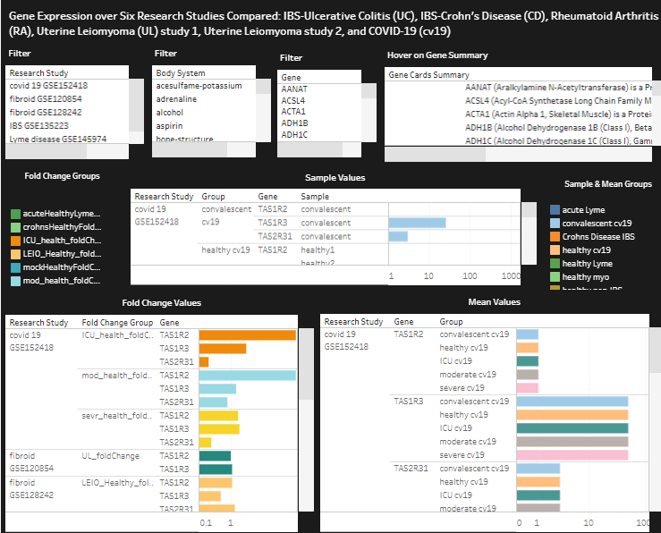

image of dashboard of all 6 studies

In this study there are three filters at the top left of the dashboard that will filter by research study, then body system or genecards.org topic for top genes, and also by gene. You don’t have to select an item from each filter, but the three charts in the dashboard as well as the Gene Cards gene summary will zoom in on that filtered data if you do. To go back to all or to deselect, just select each selected item again to remove the highlight. There are two color legends. The middle left legend is for the fold change groups within each study that displays at the bottom left. The middle right legend displays the individual sample and group gene expression values on a log scale within Tableau’s chart options. Unfortunately some nulls appeared in Tableau when uploading the data approximately 2 GB in size. Sometimes it can be finicky on character strings as well, but all three gene summaries did not cause a problem in Tableau today.